# Non-stationary conditional extremes for BC streamflow: the code report (v4, meeting-62 rebuild)

# 10 Stage 5: the three conditional functionals (v8 6, eq. 14, p. 16)

The professor’s three summaries, read off one generated cloud per reference year, all at the display day of year: the conditional mean, the conditional quantiles, and the band probability — demonstrated twice: $P_{co}$ (BRIDG above its own day’s $u(t;\tau^{*})$ while NTHMB is extreme) and $P_{band}$ (bounds at the day’s marginal 0.95 and 0.995 quantiles). Bounds and conditioning level are YAML parameters. On the Laplace scale the band bounds are flat numbers, so the probabilities need no margin inversion; the mean does, through the day’s $F^{-1}$.

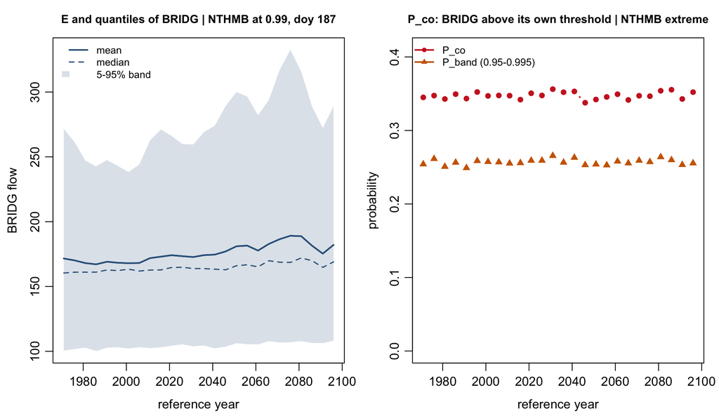

```r
cond_summaries <- function(level, tgrid_yr, cv_full, Ztab, ladderX, gpX) {
  y_lo <- qlap(params$band_lo); y_hi <- qlap(params$band_hi)
  t(sapply(tgrid_yr, function(Yr) {
    pdE <- at_day(cv_full, Yr)
    yc <- qlap(level + (1 - level) * runif(params$n_mc))
    z <- sample(Ztab, params$n_mc, replace = TRUE)
    yx <- pdE$a * yc + yc^pdE$b * (pdE$m + pdE$s * z)
    px <- pmin(pmax(plap(yx), 1 / (4 * N)), 1 - 1e-9)
    flows <- q_inv(px, ladderX, gpX, pdE$idx)
    c(mean = mean(flows),
      q05 = unname(quantile(flows, 0.05)),
      q50 = unname(quantile(flows, 0.50)),
      q95 = unname(quantile(flows, 0.95)),
      P_co = mean(yx > y_star),
      P_band = mean(yx >= y_lo & yx <= y_hi))
  }))
}
csum <- cond_summaries(params$cond_level, Ygrid, cs_full, Ztable, mX, gX)

op <- par(mfrow = c(1, 2), mar = c(3.5, 3.5, 2.5, 1), mgp = c(2.2, 0.7, 0))
plot(Ygrid, csum[, "mean"], type = "l", lwd = 2, col = "steelblue4",
     ylim = range(csum[, c("q05", "q95")]), xlab = "reference year",
     ylab = "BRIDG flow",
     main = sprintf("E and quantiles of BRIDG | NTHMB at %.2f, doy %d",
                    params$cond_level, doy_star), cex.main = 0.9)
polygon(c(Ygrid, rev(Ygrid)), c(csum[, "q05"], rev(csum[, "q95"])),
        col = adjustcolor("steelblue4", 0.18), border = NA)
lines(Ygrid, csum[, "mean"], lwd = 2, col = "steelblue4")
lines(Ygrid, csum[, "q50"], lwd = 1.5, lty = 2, col = "steelblue4")
legend("topleft", c("mean", "median", "5-95% band"), bty = "n", cex = 0.8,
       col = "steelblue4", lty = c(1, 2, NA), lwd = c(2, 1.5, NA),
       fill = c(NA, NA, adjustcolor("steelblue4", 0.18)),
       border = c(NA, NA, NA))
plot(Ygrid, csum[, "P_co"], type = "b", pch = 16, lwd = 2,
     col = "firebrick3", ylim = c(0, max(csum[, "P_co"]) * 1.15),
     xlab = "reference year", ylab = "probability",
     main = "P_co: BRIDG above its own threshold | NTHMB extreme",
     cex.main = 0.9)
lines(Ygrid, csum[, "P_band"], type = "b", pch = 17, lwd = 2,
      col = "darkorange3")
legend("topleft", c("P_co", sprintf("P_band (%.3g-%.3g)", params$band_lo,
                                    params$band_hi)),
       col = c("firebrick3", "darkorange3"), pch = c(16, 17), lwd = 2,
       bty = "n", cex = 0.8)
```

```r
par(op)

yr3 <- Ygrid[c(1, ceiling(length(Ygrid) / 2), length(Ygrid))]
knitr::kable(round(csum[Ygrid %in% yr3, ], 3),
             caption = sprintf("The three-year table (years %s, doy %d):
             the three functionals at conditioning level %.2f.",
             paste(yr3, collapse = ", "), doy_star, params$cond_level))
```

The three-year table (years 1971, 2031, 2096, doy 187): the three functionals at conditioning level 0.99.

| mean | q05 | q50 | q95 | P_co | P_band |
| --- | --- | --- | --- | --- | --- |
| 171.579 | 100.563 | 160.394 | 271.635 | 0.345 | 0.254 |
| 172.717 | 103.839 | 163.850 | 259.567 | 0.356 | 0.266 |
| 182.097 | 108.158 | 168.964 | 289.078 | 0.352 | 0.256 |

## 10.1 The HT04 Table-5 discipline: model vs empirical, where the data can check

```r
eras2 <- list(early = min(years):(min(years) + 29),
              late = (max(years) - 29):max(years))
t5 <- do.call(rbind, lapply(names(eras2), function(en) {
  yrs_e <- eras2[[en]]
  emp_days <- which(keep & years %in% yrs_e)
  emp <- mean(xX[emp_days])
  ## generate at the OBSERVED exceedance days of the era (their own year
  ## and day of year), so the comparison is day-matched, not day-averaged
  gen_days <- sample(emp_days, params$n_mc, replace = TRUE)
  yc <- qlap(params$kappa + (1 - params$kappa) * runif(params$n_mc))
  z <- sample(Ztable, params$n_mc, replace = TRUE)
  a_d <- cs_full$a[gen_days]; b_d <- cs_full$b[gen_days]
  m_d <- cs_full$m[gen_days]; s_d <- cs_full$s[gen_days]
  yx <- a_d * yc + yc^b_d * (m_d + s_d * z)
  px <- pmin(pmax(plap(yx), 1 / (4 * N)), 1 - 1e-9)
  gen <- mean(sapply(seq_len(params$n_mc), function(i)
    q_inv(px[i], mX, gX, gen_days[i])))
  data.frame(era = en, empirical = round(emp, 1), model = round(gen, 1),
             rel_gap = round(abs(emp - gen) / emp, 3))
}))
knitr::kable(t5, row.names = FALSE,
             caption = "Model vs empirical conditional mean of BRIDG flow
             given NTHMB above the dependence threshold, per era, generated
             at the observed exceedance days themselves (day-matched).
             Agreement here is the licence for the higher-level
             extrapolations above (HT04 Table 5 discipline).")
```

Model vs empirical conditional mean of BRIDG flow given NTHMB above the dependence threshold, per era, generated at the observed exceedance days themselves (day-matched). Agreement here is the licence for the higher-level extrapolations above (HT04 Table 5 discipline).

| era | empirical | model | rel_gap |
| --- | --- | --- | --- |
| early | 80.5 | 80.9 | 0.005 |
| late | 39.6 | 42.9 | 0.084 |

# 11 Uncertainty: the block bootstrap (v8 6, p. 15)

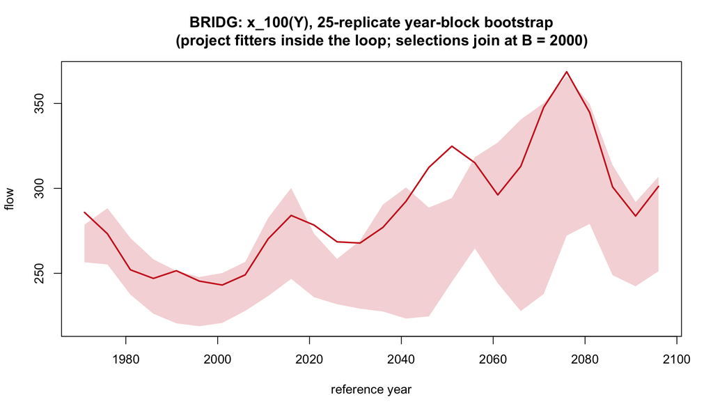

```r
boot_once <- function() {
  yrs <- unique(years)
  keep_y <- years %in% sample(yrs, replace = TRUE)
  gX_b <- pen_rq_seas(xX[keep_y], Xseas[keep_y, ], params$tau_star,
                      ifelse(is.na(mX$lam_u), 100, mX$lam_u))
  uX_b <- as.vector(Xseas %*% gX_b)
  e <- xX > uX_b & keep_y
  gpX_b <- fit_gp_basis((xX - uX_b)[e], Xseas[e, , drop = FALSE],
                        gX$lam_s, Dtr)
  th_b <- ferro_segers(which(xX > uX_b))
  kb <- YC > v_dep & keep_y
  hb <- fit_ht_basis(YC[kb], YX[kb], cbind(1, tt[kb]),
                     Bchk = cbind(1, tdec))
  sigX_b <- exp(as.vector(Xseas %*% gpX_b$gam))
  U_b <- mX$U; U_b[, K] <- uX_b
  list(rl100 = sapply(Ygrid, function(Yr)
         rl_root(Yr, 100, U = U_b, sig = sigX_b, xi = gpX_b$xi,
                 theta = th_b)),
       a_ends = 2 * plogis(hb$par[1] + hb$par[2] * c(0, 1)) - 1)
}
boots <- replicate(params$B_boot, boot_once(), simplify = FALSE)
rl_mat <- sapply(boots, `[[`, "rl100")
a_mat <- sapply(boots, `[[`, "a_ends")
bandr <- apply(rl_mat, 1, quantile, c(0.025, 0.975), na.rm = TRUE)
plot(Ygrid, rlX[, 3], type = "n",
     ylim = range(bandr, rlX[, 3], na.rm = TRUE),
     xlab = "reference year", ylab = "flow",
     main = sprintf("BRIDG: x_100(Y), %d-replicate year-block bootstrap
     (project fitters inside the loop; selections join at B = 2000)",
                    params$B_boot))
polygon(c(Ygrid, rev(Ygrid)), c(bandr[1, ], rev(bandr[2, ])),
        col = adjustcolor("firebrick3", 0.2), border = NA)
lines(Ygrid, rlX[, 3], lwd = 2, col = "firebrick3")
```

```r
a_ci <- apply(a_mat, 1, quantile, c(0.025, 0.975))
a_lin_ends <- 2 * plogis(h1$par[1] + h1$par[2] * c(0, 1)) - 1
knitr::kable(data.frame(endpoint = c("axis start", "axis end"),
  a_hat = round(a_lin_ends, 3),
  lo = round(a_ci[1, ], 3), hi = round(a_ci[2, ], 3)),
  caption = "The honest move-one test at the dependence stage (v8 Sec 4.6,
  p. 10): year-block bootstrap intervals for a(t) at the axis endpoints,
  Laplace scale.")
```

The honest move-one test at the dependence stage (v8 Sec 4.6, p. 10): year-block bootstrap intervals for a(t) at the axis endpoints, Laplace scale.

| endpoint | a_hat | lo | hi |
| --- | --- | --- | --- |
| axis start | 0.095 | -0.117 | 0.137 |
| axis end | 0.095 | -0.483 | 0.175 |

**Reading the figure and the table.** The red curve is the production 100-year level for BRIDG; the band its bootstrap 95% interval — years resampled with their labels kept, threshold, GP, $\theta$ and the linear dependence model refitted per replicate, so the band measures estimation uncertainty on the same axis (v8 6, p. 15). A band at the late axis that excludes the early-axis level is the uncertainty-aware “the risk changed.” The table gives the bootstrap answer for the dependence trend: the interval at the axis end excluding the interval at the start is what certifies the working-likelihood LRT’s verdict (v8 4.6, p. 10). At $B = 25$ these are knit-scale indications; the paper-scale run is $B = 2000$ with every selection inside the loop.

# 12 The RCP 8.5 arm (v8 6, p. 16)

The scenario comparison — the display contrast the meeting settled on — needs the RCP 8.5 series in the same schema as this file (station, date, sf, bf; 1969–2099). Once that export exists, this report’s pipeline runs on it unchanged (the axis is read from the file), and the scenario-contrast versions of the pseudosample display and the functionals replace the within-scenario year contrast. Blocked on the data export; nothing else here waits on it.

# 13 Standing items, and the Friday list

Cleaning: the forensics tables above are evidence, not decisions — which values or months to exclude, and how to document it, is decided with the professor; 1968 is already out. The three problems (data, threshold, excesses + PIT) map to Sections 2, 3 and 4–5. For Friday: confirm the identity of “the three problems”; the display scale (standard vs original, Section 7 draws both); whether the year contrast on the original-scale panel is wanted alongside the scenario contrast; and the seasonal-threshold consequence flagged in the preamble — with margins that bend within the year, the dependence stage conditions on season-relative extremes, and that reading should be agreed explicitly. Laplace is the working scale throughout (v8 3); the Gumbel refit remains available as the sensitivity appendix v8 7 (p. 17) names. Reproducibility: seed 20260818 once at the top; knit-scale settings are the YAML parameters.